# 08 Financial Autoencoder 1M Normal Sample Experiment

Notebook 03 selected the final supervised ML model for the PaySim V1 workflow. This notebook explores an Autoencoder as an unsupervised/semi-supervised anomaly detection component.

This notebook is a sample-size sensitivity experiment based on notebook 04. It keeps the Autoencoder architectures, review policy, threshold selection logic, preprocessing, and train/validation/test split unchanged, but increases the normal-only Autoencoder training sample size from 500,000 to 1,000,000. The goal is to check whether learning from more normal transactions improves anomaly detection performance.

The Autoencoder is trained on normal transactions only. It learns reconstruction patterns from normal transaction behavior, and row-level reconstruction error is used as an anomaly score.

The Autoencoder is not intended to outperform or replace the supervised Random Forest classifier. Instead, it provides a complementary anomaly detection signal that may help identify transactions that deviate from normal transaction behavior.

Validation data is used for threshold selection and Autoencoder configuration comparison. The test set is used only once for final Autoencoder evaluation. The resulting anomaly signal will later be integrated with supervised fraud probability and business rules in notebook 05.

For this fraud review use case, the Autoencoder is used to generate a review signal, not a final fraud classifier. The review policy is recall-oriented: missing fraud is considered more costly than reviewing some additional suspicious transactions. Therefore, threshold and configuration selection prioritize recall while constraining the predicted anomaly rate to avoid an excessive review queue.

## 1. Import Libraries and Project Modules

The notebook is designed to run from the `notebooks/` folder while importing reusable functions from `src/`.

```python
import sys
from pathlib import Path

import joblib
import numpy as np
import pandas as pd
import matplotlib.pyplot as plt

from sklearn.model_selection import train_test_split

PROJECT_ROOT = Path.cwd().parent if Path.cwd().name == "notebooks" else Path.cwd()
if str(PROJECT_ROOT) not in sys.path:
    sys.path.insert(0, str(PROJECT_ROOT))

from src.preprocessing import (
    load_paysim_data,
    create_engineered_features,
    prepare_features_and_target,
    get_feature_columns,
    build_preprocessor,
)

from src.train_autoencoder import (
    set_autoencoder_random_seed,
    get_normal_training_data,
    sample_normal_training_data,
    transform_autoencoder_features,
    get_autoencoder_configurations,
    tune_autoencoder_configurations_for_review_policy,
    select_best_autoencoder_config_for_review_policy,
    calculate_reconstruction_errors,
    evaluate_autoencoder_anomaly_detector,
    create_reconstruction_error_dataframe,
    create_training_history_dataframe,
    save_autoencoder_artifacts,
)

RANDOM_STATE = 42
set_autoencoder_random_seed(RANDOM_STATE)

REPORTS_DIR = PROJECT_ROOT / "reports"
AUTOENCODER_MODEL_DIR = PROJECT_ROOT / "models" / "autoencoder_1m"
REPORTS_DIR.mkdir(parents=True, exist_ok=True)
AUTOENCODER_MODEL_DIR.mkdir(parents=True, exist_ok=True)

print(f"Project root: {PROJECT_ROOT}")
print(f"Reports directory: {REPORTS_DIR}")
print(f"Autoencoder model directory: {AUTOENCODER_MODEL_DIR}")
```

```
Project root: d:\cs s1 26\基于深度学习的交易欺诈检测与智能风控系统\transaction-fraud-detection-system
Reports directory: d:\cs s1 26\基于深度学习的交易欺诈检测与智能风控系统\transaction-fraud-detection-system\reports
Autoencoder model directory: d:\cs s1 26\基于深度学习的交易欺诈检测与智能风控系统\transaction-fraud-detection-system\models\autoencoder_1m
```

## 2. Load and Prepare PaySim Data

This notebook repeats the preprocessing and split logic so it can run independently and remain comparable with notebook 02 and notebook 03.

```python
DATA_PATH = PROJECT_ROOT / "data" / "raw" / "PS_20174392719_1491204439457_log.csv"

# The current project structure stores PaySim under data/raw/financial/paysim.csv.
# This fallback keeps the notebook runnable with the existing repository layout.
if not DATA_PATH.exists():
    DATA_PATH = PROJECT_ROOT / "data" / "raw" / "financial" / "paysim.csv"

print(f"Dataset path: {DATA_PATH}")

df = load_paysim_data(DATA_PATH)
df = create_engineered_features(df)
X, y = prepare_features_and_target(df)

print(f"Raw dataset shape after feature engineering: {df.shape}")
print(f"Feature matrix shape: {X.shape}")
print("Target distribution:")
print(y.value_counts())
print(f"Fraud rate: {y.mean():.6f}")
```

```
Dataset path: d:\cs s1 26\基于深度学习的交易欺诈检测与智能风控系统\transaction-fraud-detection-system\data\raw\financial\paysim.csv
Raw dataset shape after feature engineering: (6362620, 20)
Feature matrix shape: (6362620, 16)
Target distribution:
isFraud
0    6354407
1       8213
Name: count, dtype: int64
Fraud rate: 0.001291
```

## 3. Recreate Train / Validation / Test Split

The split strategy mirrors notebook 03: first create an untouched holdout test set, then split the remaining data into training and validation sets. Validation is used for Autoencoder threshold and configuration selection. Test data is preserved for final evaluation only.

Validation and test sets are not sampled.

```python
X_trainval_full, X_test, y_trainval_full, y_test = train_test_split(
    X,
    y,
    test_size=0.2,
    stratify=y,
    random_state=RANDOM_STATE,
)

X_train_full, X_val, y_train_full, y_val = train_test_split(
    X_trainval_full,
    y_trainval_full,
    test_size=0.25,
    stratify=y_trainval_full,
    random_state=RANDOM_STATE,
)

def print_split_summary(name, X_part, y_part):
    fraud_count = int(y_part.sum())
    fraud_rate = y_part.mean()
    print(
        f"{name}: X shape={X_part.shape}, y shape={y_part.shape}, "
        f"fraud_count={fraud_count}, fraud_rate={fraud_rate:.6f}"
    )

print_split_summary("Train full", X_train_full, y_train_full)
print_split_summary("Validation", X_val, y_val)
print_split_summary("Test", X_test, y_test)
```

```
Train full: X shape=(3817572, 16), y shape=(3817572,), fraud_count=4928, fraud_rate=0.001291
Validation: X shape=(1272524, 16), y shape=(1272524,), fraud_count=1642, fraud_rate=0.001290
Test: X shape=(1272524, 16), y shape=(1272524,), fraud_count=1643, fraud_rate=0.001291
```

## 4. Extract Normal Training Transactions

The Autoencoder is trained only on normal transactions so that reconstruction error reflects deviation from normal transaction behavior.

PaySim contains many normal transactions, so a random sample of normal training rows is used to keep the experiment manageable. Sampling is applied only to the training data, never to validation or test data.

```python
N_NORMAL_AUTOENCODER = 1_000_000

X_train_normal, y_train_normal = get_normal_training_data(
    X_train_full,
    y_train_full,
)

X_train_normal_sampled, y_train_normal_sampled = sample_normal_training_data(
    X_train_normal,
    y_train_normal,
    n_samples=N_NORMAL_AUTOENCODER,
    random_state=RANDOM_STATE,
)

print(f"Normal training full shape: {X_train_normal.shape}")
print(f"Sampled normal training shape: {X_train_normal_sampled.shape}")
print("Sampled normal training target distribution:")
print(y_train_normal_sampled.value_counts())
print(f"Contains only normal transactions: {(y_train_normal_sampled == 0).all()}")
```

```
Normal training full shape: (3812644, 16)
Sampled normal training shape: (1000000, 16)
Sampled normal training target distribution:
isFraud
0    1000000
Name: count, dtype: int64
Contains only normal transactions: True
```

## 5. Build and Fit Autoencoder Preprocessor

The Autoencoder preprocessor is fitted only on normal training transactions. Validation and test sets are transformed using the fitted preprocessor to avoid data leakage.

```python
numeric_features, categorical_features = get_feature_columns()
preprocessor = build_preprocessor(numeric_features, categorical_features)

(
    fitted_ae_preprocessor,
    X_train_normal_ae,
    X_val_ae,
    X_test_ae,
) = transform_autoencoder_features(
    preprocessor,
    X_train_normal_sampled,
    X_val,
    X_test,
)

input_dim = X_train_normal_ae.shape[1]

print(f"Transformed normal train shape: {X_train_normal_ae.shape}")
print(f"Transformed validation shape: {X_val_ae.shape}")
print(f"Transformed test shape: {X_test_ae.shape}")
print(f"Autoencoder input dimension: {input_dim}")
```

```
Transformed normal train shape: (1000000, 19)
Transformed validation shape: (1272524, 19)
Transformed test shape: (1272524, 19)
Autoencoder input dimension: 19
```

## 6. Define Autoencoder Configurations

Only a small set of Autoencoder architectures is compared because this module is intended as a supplementary anomaly detection signal, not the primary classifier.

```python
configs = get_autoencoder_configurations()
configs_df = pd.DataFrame(configs)
configs_df
```

|  | config_name | encoding_dims | dropout_rate | learning_rate | batch_size | epochs | patience |
| --- | --- | --- | --- | --- | --- | --- | --- |
| 0 | small_autoencoder | (32, 16, 8) | 0.1 | 0.001 | 2048 | 30 | 5 |
| 1 | medium_autoencoder | (64, 32, 16) | 0.1 | 0.001 | 2048 | 30 | 5 |
| 2 | regularized_autoencoder | (64, 32, 16) | 0.2 | 0.001 | 2048 | 30 | 5 |
| 3 | narrow_bottleneck_autoencoder | (64, 16, 8) | 0.1 | 0.001 | 2048 | 50 | 7 |
| 4 | wide_regularized_autoencoder | (128, 64, 32) | 0.2 | 0.001 | 2048 | 50 | 7 |

## 7. Train and Tune Autoencoder Configurations

Validation labels are used only for threshold selection and configuration comparison. Test labels are not used in this stage.

`MAX_REVIEW_RATE = 0.01` means that at most around 1% of transactions are sent to review during validation threshold selection. This keeps the review queue manageable while prioritizing fraud recall.

This final refinement searches more densely around the previous selected threshold region. The goal is to use the available review budget more effectively by increasing recall while keeping the predicted anomaly rate below the 1% review cap.

```python
candidate_percentiles = (
    98.8,
    98.9,
    99.0,
    99.05,
    99.1,
    99.15,
    99.2,
    99.25,
    99.3,
    99.4,
    99.5,
    99.6,
    99.7,
    99.8,
    99.9,
    99.95,
)
MAX_REVIEW_RATE = 0.01
MIN_PRECISION = 0.05

(
    fitted_models,
    histories,
    thresholds,
    threshold_results,
    validation_results_df,
) = tune_autoencoder_configurations_for_review_policy(
    configs=configs,
    X_train_normal=X_train_normal_ae,
    X_val=X_val_ae,
    y_val=y_val,
    candidate_percentiles=candidate_percentiles,
    max_review_rate=MAX_REVIEW_RATE,
    min_precision=MIN_PRECISION,
    verbose=1,
)

validation_results_df = validation_results_df.sort_values(
    by=["recall", "precision", "f1", "pr_auc"],
    ascending=False,
).reset_index(drop=True)

validation_results_path = REPORTS_DIR / "autoencoder_1m_validation_results.csv"
validation_results_df.to_csv(validation_results_path, index=False)

print(f"Saved validation results to: {validation_results_path}")
display_columns = [
    "config_name",
    "selected_percentile",
    "threshold",
    "precision",
    "recall",
    "f1",
    "pr_auc",
    "fp",
    "fn",
    "tp",
    "predicted_anomaly_rate",
    "max_review_rate",
    "review_policy_satisfied",
]
validation_results_df[display_columns]
```

```
Training small_autoencoder with review-policy threshold selection...
WARNING:tensorflow:TensorFlow GPU support is not available on native Windows for TensorFlow >= 2.11. Even if CUDA/cuDNN are installed, GPU will not be used. Please use WSL2 or the TensorFlow-DirectML plugin.
440/440 ━━━━━━━━━━━━━━━━━━━━ 25s 17ms/step - loss: 0.5529 - val_loss: 0.1793 - learning_rate: 0.0010
440/440 ━━━━━━━━━━━━━━━━━━━━ 7s 16ms/step - loss: 0.2920 - val_loss: 0.1386 - learning_rate: 0.0010
440/440 ━━━━━━━━━━━━━━━━━━━━ 7s 17ms/step - loss: 0.2458 - val_loss: 0.1003 - learning_rate: 0.0010
440/440 ━━━━━━━━━━━━━━━━━━━━ 6s 13ms/step - loss: 0.2138 - val_loss: 0.0775 - learning_rate: 0.0010
440/440 ━━━━━━━━━━━━━━━━━━━━ 8s 17ms/step - loss: 0.1972 - val_loss: 0.0684 - learning_rate: 0.0010
440/440 ━━━━━━━━━━━━━━━━━━━━ 7s 15ms/step - loss: 0.1847 - val_loss: 0.0624 - learning_rate: 0.0010
440/440 ━━━━━━━━━━━━━━━━━━━━ 7s 15ms/step - loss: 0.1740 - val_loss: 0.0584 - learning_rate: 0.0010
440/440 ━━━━━━━━━━━━━━━━━━━━ 7s 16ms/step - loss: 0.1653 - val_loss: 0.0557 - learning_rate: 0.0010
440/440 ━━━━━━━━━━━━━━━━━━━━ 7s 16ms/step - loss: 0.1580 - val_loss: 0.0473 - learning_rate: 0.0010
440/440 ━━━━━━━━━━━━━━━━━━━━ 7s 16ms/step - loss: 0.1541 - val_loss: 0.0488 - learning_rate: 0.0010
440/440 ━━━━━━━━━━━━━━━━━━━━ 7s 15ms/step - loss: 0.1504 - val_loss: 0.0458 - learning_rate: 0.0010
440/440 ━━━━━━━━━━━━━━━━━━━━ 6s 13ms/step - loss: 0.1468 - val_loss: 0.0428 - learning_rate: 0.0010
440/440 ━━━━━━━━━━━━━━━━━━━━ 7s 15ms/step - loss: 0.1475 - val_loss: 0.0447 - learning_rate: 0.0010
440/440 ━━━━━━━━━━━━━━━━━━━━ 6s 13ms/step - loss: 0.1440 - val_loss: 0.0451 - learning_rate: 0.0010
440/440 ━━━━━━━━━━━━━━━━━━━━ 7s 15ms/step - loss: 0.1422 - val_loss: 0.0437 - learning_rate: 5.0000e-04
440/440 ━━━━━━━━━━━━━━━━━━━━ 6s 13ms/step - loss: 0.1407 - val_loss: 0.0435 - learning_rate: 5.0000e-04
440/440 ━━━━━━━━━━━━━━━━━━━━ 7s 15ms/step - loss: 0.1404 - val_loss: 0.0427 - learning_rate: 2.5000e-04
440/440 ━━━━━━━━━━━━━━━━━━━━ 6s 14ms/step - loss: 0.1378 - val_loss: 0.0434 - learning_rate: 2.5000e-04
440/440 ━━━━━━━━━━━━━━━━━━━━ 7s 15ms/step - loss: 0.1381 - val_loss: 0.0428 - learning_rate: 1.2500e-04
440/440 ━━━━━━━━━━━━━━━━━━━━ 8s 17ms/step - loss: 0.1371 - val_loss: 0.0435 - learning_rate: 1.2500e-04
440/440 ━━━━━━━━━━━━━━━━━━━━ 7s 15ms/step - loss: 0.1375 - val_loss: 0.0430 - learning_rate: 6.2500e-05
440/440 ━━━━━━━━━━━━━━━━━━━━ 7s 15ms/step - loss: 0.1371 - val_loss: 0.0427 - learning_rate: 6.2500e-05
440/440 ━━━━━━━━━━━━━━━━━━━━ 7s 15ms/step - loss: 0.1356 - val_loss: 0.0428 - learning_rate: 6.2500e-05
440/440 ━━━━━━━━━━━━━━━━━━━━ 7s 16ms/step - loss: 0.1347 - val_loss: 0.0430 - learning_rate: 6.2500e-05
440/440 ━━━━━━━━━━━━━━━━━━━━ 7s 16ms/step - loss: 0.1358 - val_loss: 0.0423 - learning_rate: 3.1250e-05
440/440 ━━━━━━━━━━━━━━━━━━━━ 7s 16ms/step - loss: 0.1379 - val_loss: 0.0421 - learning_rate: 3.1250e-05
440/440 ━━━━━━━━━━━━━━━━━━━━ 8s 17ms/step - loss: 0.1386 - val_loss: 0.0429 - learning_rate: 3.1250e-05
440/440 ━━━━━━━━━━━━━━━━━━━━ 8s 17ms/step - loss: 0.1362 - val_loss: 0.0430 - learning_rate: 3.1250e-05
440/440 ━━━━━━━━━━━━━━━━━━━━ 7s 15ms/step - loss: 0.1359 - val_loss: 0.0431 - learning_rate: 1.5625e-05
440/440 ━━━━━━━━━━━━━━━━━━━━ 6s 13ms/step - loss: 0.1363 - val_loss: 0.0428 - learning_rate: 1.5625e-05
Training medium_autoencoder with review-policy threshold selection...
440/440 ━━━━━━━━━━━━━━━━━━━━ 23s 33ms/step - loss: 0.4132 - val_loss: 0.0616 - learning_rate: 0.0010
440/440 ━━━━━━━━━━━━━━━━━━━━ 13s 30ms/step - loss: 0.1739 - val_loss: 0.0451 - learning_rate: 0.0010
440/440 ━━━━━━━━━━━━━━━━━━━━ 16s 36ms/step - loss: 0.1359 - val_loss: 0.0358 - learning_rate: 0.0010
440/440 ━━━━━━━━━━━━━━━━━━━━ 13s 29ms/step - loss: 0.1208 - val_loss: 0.0304 - learning_rate: 0.0010
440/440 ━━━━━━━━━━━━━━━━━━━━ 13s 30ms/step - loss: 0.1106 - val_loss: 0.0306 - learning_rate: 0.0010
440/440 ━━━━━━━━━━━━━━━━━━━━ 14s 32ms/step - loss: 0.1038 - val_loss: 0.0282 - learning_rate: 0.0010
440/440 ━━━━━━━━━━━━━━━━━━━━ 13s 29ms/step - loss: 0.0974 - val_loss: 0.0301 - learning_rate: 0.0010
```

[output cut: 60 more lines]

```
440/440 ━━━━━━━━━━━━━━━━━━━━ 14s 32ms/step - loss: 0.0929 - val_loss: 0.0255 - learning_rate: 0.0010
440/440 ━━━━━━━━━━━━━━━━━━━━ 14s 32ms/step - loss: 0.0895 - val_loss: 0.0301 - learning_rate: 0.0010
440/440 ━━━━━━━━━━━━━━━━━━━━ 14s 32ms/step - loss: 0.0882 - val_loss: 0.0549 - learning_rate: 0.0010
440/440 ━━━━━━━━━━━━━━━━━━━━ 14s 31ms/step - loss: 0.0859 - val_loss: 0.0545 - learning_rate: 0.0010
440/440 ━━━━━━━━━━━━━━━━━━━━ 15s 33ms/step - loss: 0.0830 - val_loss: 0.0414 - learning_rate: 5.0000e-04
440/440 ━━━━━━━━━━━━━━━━━━━━ 14s 32ms/step - loss: 0.0810 - val_loss: 0.0281 - learning_rate: 5.0000e-04
440/440 ━━━━━━━━━━━━━━━━━━━━ 14s 31ms/step - loss: 0.0792 - val_loss: 0.0247 - learning_rate: 5.0000e-04
440/440 ━━━━━━━━━━━━━━━━━━━━ 14s 32ms/step - loss: 0.0791 - val_loss: 0.0293 - learning_rate: 5.0000e-04
440/440 ━━━━━━━━━━━━━━━━━━━━ 14s 32ms/step - loss: 0.0782 - val_loss: 0.0330 - learning_rate: 5.0000e-04
440/440 ━━━━━━━━━━━━━━━━━━━━ 14s 32ms/step - loss: 0.0772 - val_loss: 0.0384 - learning_rate: 5.0000e-04
440/440 ━━━━━━━━━━━━━━━━━━━━ 14s 31ms/step - loss: 0.0758 - val_loss: 0.0285 - learning_rate: 2.5000e-04
440/440 ━━━━━━━━━━━━━━━━━━━━ 14s 32ms/step - loss: 0.0742 - val_loss: 0.0257 - learning_rate: 2.5000e-04
440/440 ━━━━━━━━━━━━━━━━━━━━ 14s 32ms/step - loss: 0.0748 - val_loss: 0.0284 - learning_rate: 2.5000e-04
440/440 ━━━━━━━━━━━━━━━━━━━━ 14s 31ms/step - loss: 0.0739 - val_loss: 0.0342 - learning_rate: 1.2500e-04
Saved validation results to: d:\cs s1 26\基于深度学习的交易欺诈检测与智能风控系统\transaction-fraud-detection-system\reports\autoencoder_1m_validation_results.csv
```

|  | config_name | selected_percentile | threshold | precision | recall | f1 | pr_auc | fp | fn | tp | predicted_anomaly_rate | max_review_rate | review_policy_satisfied |
| --- | --- | --- | --- | --- | --- | --- | --- | --- | --- | --- | --- | --- | --- |
| 0 | small_autoencoder | 99.05 | 0.384202 | 0.069485 | 0.511571 | 0.122351 | 0.295107 | 11249 | 802 | 840 | 0.0095 | 0.01 | True |
| 1 | regularized_autoencoder | 99.05 | 0.421206 | 0.065597 | 0.482948 | 0.115505 | 0.267412 | 11296 | 849 | 793 | 0.0095 | 0.01 | True |
| 2 | narrow_bottleneck_autoencoder | 99.05 | 0.404964 | 0.064356 | 0.473812 | 0.113320 | 0.261242 | 11311 | 864 | 778 | 0.0095 | 0.01 | True |
| 3 | wide_regularized_autoencoder | 99.05 | 0.180326 | 0.064191 | 0.472594 | 0.113029 | 0.177791 | 11313 | 866 | 776 | 0.0095 | 0.01 | True |
| 4 | medium_autoencoder | 99.05 | 0.173986 | 0.064025 | 0.471376 | 0.112738 | 0.234950 | 11315 | 868 | 774 | 0.0095 | 0.01 | True |

## 8. Visualize Training History

The training curves help check whether the Autoencoder converged and whether there are signs of overfitting.

```python
history_df = create_training_history_dataframe(histories)
history_df.head()
```

|  | config_name | epoch | loss | val_loss |
| --- | --- | --- | --- | --- |
| 0 | small_autoencoder | 1 | 0.552896 | 0.179267 |
| 1 | small_autoencoder | 2 | 0.291982 | 0.138596 |
| 2 | small_autoencoder | 3 | 0.245776 | 0.100287 |
| 3 | small_autoencoder | 4 | 0.213784 | 0.077510 |
| 4 | small_autoencoder | 5 | 0.197224 | 0.068437 |

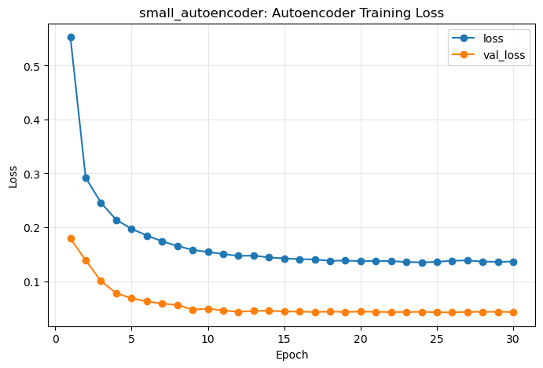

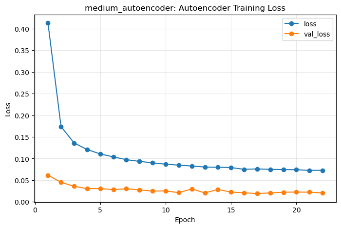

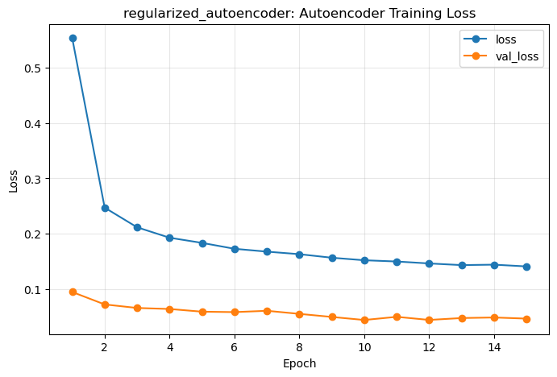

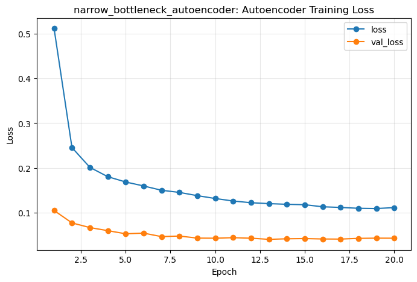

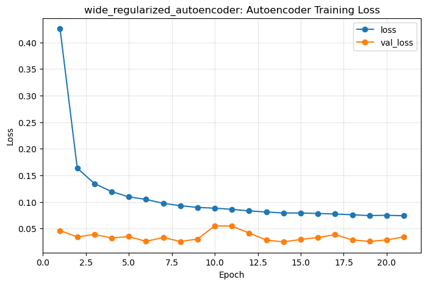

```python
for config_name in history_df["config_name"].unique():
    config_history = history_df[history_df["config_name"] == config_name]

    plt.figure(figsize=(8, 5))
    plt.plot(config_history["epoch"], config_history["loss"], marker="o", label="loss")

    if "val_loss" in config_history.columns and config_history["val_loss"].notna().any():
        plt.plot(config_history["epoch"], config_history["val_loss"], marker="o", label="val_loss")

    plt.title(f"{config_name}: Autoencoder Training Loss")
    plt.xlabel("Epoch")
    plt.ylabel("Loss")
    plt.legend()
    plt.grid(True, alpha=0.3)
    plt.show()
```

## 9. Visualize Validation Threshold Trade-Offs

Lower percentile thresholds usually increase recall but send more transactions to review. Higher percentile thresholds reduce review volume but may miss more fraud. The selected threshold should maximize recall under the review-rate constraint.

```
Threshold results for small_autoencoder
```

|  | percentile | threshold | precision | recall | f1 | tn | fp | fn | tp | predicted_anomalies | predicted_anomaly_rate |
| --- | --- | --- | --- | --- | --- | --- | --- | --- | --- | --- | --- |
| 0 | 99.95 | 5.886664 | 0.642072 | 0.249086 | 0.358929 | 1270654 | 228 | 1233 | 409 | 637 | 0.000501 |
| 1 | 99.90 | 3.379517 | 0.389631 | 0.302071 | 0.340309 | 1270105 | 777 | 1146 | 496 | 1273 | 0.001000 |
| 2 | 99.80 | 1.713277 | 0.233399 | 0.361754 | 0.283735 | 1268931 | 1951 | 1048 | 594 | 2545 | 0.002000 |
| 3 | 99.70 | 1.089725 | 0.174961 | 0.406821 | 0.244689 | 1267732 | 3150 | 974 | 668 | 3818 | 0.003000 |
| 4 | 99.60 | 0.763291 | 0.141622 | 0.439099 | 0.214169 | 1266512 | 4370 | 921 | 721 | 5091 | 0.004001 |
| 5 | 99.50 | 0.614763 | 0.118655 | 0.459805 | 0.188632 | 1265274 | 5608 | 887 | 755 | 6363 | 0.005000 |
| 6 | 99.40 | 0.531979 | 0.102017 | 0.474421 | 0.167924 | 1264025 | 6857 | 863 | 779 | 7636 | 0.006001 |
| 7 | 99.30 | 0.473796 | 0.089358 | 0.484775 | 0.150900 | 1262770 | 8112 | 846 | 796 | 8908 | 0.007000 |
| 8 | 99.25 | 0.451227 | 0.084241 | 0.489647 | 0.143751 | 1262142 | 8740 | 838 | 804 | 9544 | 0.007500 |
| 9 | 99.20 | 0.431551 | 0.079658 | 0.493910 | 0.137190 | 1261512 | 9370 | 831 | 811 | 10181 | 0.008001 |
| 10 | 99.15 | 0.413933 | 0.076176 | 0.501827 | 0.132274 | 1260889 | 9993 | 818 | 824 | 10817 | 0.008500 |
| 11 | 99.10 | 0.398303 | 0.072645 | 0.506699 | 0.127071 | 1260261 | 10621 | 810 | 832 | 11453 | 0.009000 |
| 12 | 99.05 | 0.384202 | 0.069485 | 0.511571 | 0.122351 | 1259633 | 11249 | 802 | 840 | 12089 | 0.009500 |
| 13 | 99.00 | 0.370923 | 0.066714 | 0.517052 | 0.118179 | 1259005 | 11877 | 793 | 849 | 12726 | 0.010001 |
| 14 | 98.90 | 0.346729 | 0.061437 | 0.523752 | 0.109974 | 1257744 | 13138 | 782 | 860 | 13998 | 0.011000 |
| 15 | 98.80 | 0.326833 | 0.056774 | 0.528015 | 0.102525 | 1256478 | 14404 | 775 | 867 | 15271 | 0.012001 |

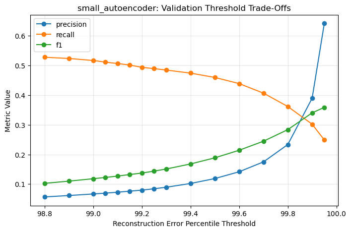

```
Threshold results for medium_autoencoder
```

|  | percentile | threshold | precision | recall | f1 | tn | fp | fn | tp | predicted_anomalies | predicted_anomaly_rate |
| --- | --- | --- | --- | --- | --- | --- | --- | --- | --- | --- | --- |
| 0 | 99.90 | 1.377741 | 0.374705 | 0.290499 | 0.327273 | 1270086 | 796 | 1165 | 477 | 1273 | 0.001000 |
| 1 | 99.95 | 3.893750 | 0.535322 | 0.207674 | 0.299254 | 1270586 | 296 | 1301 | 341 | 637 | 0.000501 |
| 2 | 99.80 | 0.539170 | 0.238900 | 0.370280 | 0.290423 | 1268945 | 1937 | 1034 | 608 | 2545 | 0.002000 |
| 3 | 99.70 | 0.382638 | 0.170770 | 0.397077 | 0.238828 | 1267716 | 3166 | 990 | 652 | 3818 | 0.003000 |
| 4 | 99.60 | 0.317726 | 0.133569 | 0.414129 | 0.201990 | 1266471 | 4411 | 962 | 680 | 5091 | 0.004001 |
| 5 | 99.50 | 0.274835 | 0.110482 | 0.428136 | 0.175640 | 1265222 | 5660 | 939 | 703 | 6363 | 0.005000 |
| 6 | 99.40 | 0.242839 | 0.093635 | 0.435445 | 0.154128 | 1263961 | 6921 | 927 | 715 | 7636 | 0.006001 |
| 7 | 99.30 | 0.218122 | 0.082510 | 0.447625 | 0.139336 | 1262709 | 8173 | 907 | 735 | 8908 | 0.007000 |
| 8 | 99.25 | 0.207759 | 0.077850 | 0.452497 | 0.132845 | 1262081 | 8801 | 899 | 743 | 9544 | 0.007500 |
| 9 | 99.20 | 0.198394 | 0.073961 | 0.458587 | 0.127379 | 1261454 | 9428 | 889 | 753 | 10181 | 0.008001 |
| 10 | 99.15 | 0.189447 | 0.070075 | 0.461632 | 0.121679 | 1260823 | 10059 | 884 | 758 | 10817 | 0.008500 |
| 11 | 99.10 | 0.181446 | 0.066882 | 0.466504 | 0.116991 | 1260195 | 10687 | 876 | 766 | 11453 | 0.009000 |
| 12 | 99.05 | 0.173986 | 0.064025 | 0.471376 | 0.112738 | 1259567 | 11315 | 868 | 774 | 12089 | 0.009500 |
| 13 | 99.00 | 0.167064 | 0.061370 | 0.475639 | 0.108714 | 1258937 | 11945 | 861 | 781 | 12726 | 0.010001 |
| 14 | 98.90 | 0.154402 | 0.057294 | 0.488429 | 0.102558 | 1257686 | 13196 | 840 | 802 | 13998 | 0.011000 |
| 15 | 98.80 | 0.143849 | 0.053566 | 0.498173 | 0.096730 | 1256429 | 14453 | 824 | 818 | 15271 | 0.012001 |

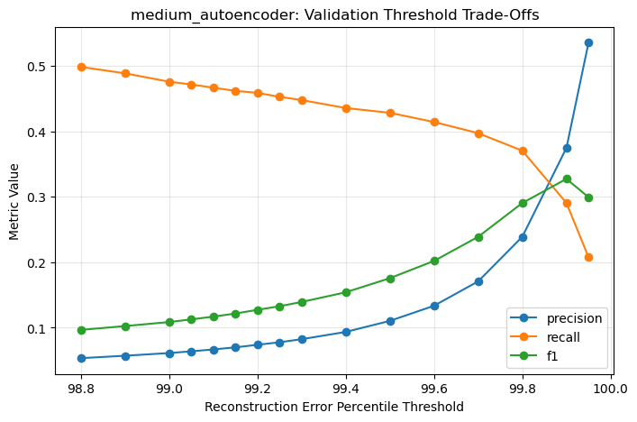

```
Threshold results for regularized_autoencoder
```

|  | percentile | threshold | precision | recall | f1 | tn | fp | fn | tp | predicted_anomalies | predicted_anomaly_rate |
| --- | --- | --- | --- | --- | --- | --- | --- | --- | --- | --- | --- |
| 0 | 99.90 | 3.925004 | 0.354281 | 0.274665 | 0.309434 | 1270060 | 822 | 1191 | 451 | 1273 | 0.001000 |
| 1 | 99.95 | 8.903852 | 0.538462 | 0.208892 | 0.301009 | 1270588 | 294 | 1299 | 343 | 637 | 0.000501 |
| 2 | 99.80 | 1.766386 | 0.222790 | 0.345311 | 0.270838 | 1268904 | 1978 | 1075 | 567 | 2545 | 0.002000 |
| 3 | 99.70 | 1.160138 | 0.165270 | 0.384287 | 0.231136 | 1267695 | 3187 | 1011 | 631 | 3818 | 0.003000 |
| 4 | 99.60 | 0.853838 | 0.133765 | 0.414738 | 0.202287 | 1266472 | 4410 | 961 | 681 | 5091 | 0.004001 |
| 5 | 99.50 | 0.691284 | 0.112054 | 0.434227 | 0.178139 | 1265232 | 5650 | 929 | 713 | 6363 | 0.005000 |
| 6 | 99.40 | 0.590296 | 0.096255 | 0.447625 | 0.158439 | 1263981 | 6901 | 907 | 735 | 7636 | 0.006001 |
| 7 | 99.30 | 0.523739 | 0.084419 | 0.457978 | 0.142559 | 1262726 | 8156 | 890 | 752 | 8908 | 0.007000 |
| 8 | 99.25 | 0.497495 | 0.079212 | 0.460414 | 0.135169 | 1262094 | 8788 | 886 | 756 | 9544 | 0.007500 |
| 9 | 99.20 | 0.474639 | 0.075336 | 0.467113 | 0.129747 | 1261468 | 9414 | 875 | 767 | 10181 | 0.008001 |
| 10 | 99.15 | 0.454532 | 0.071831 | 0.473203 | 0.124729 | 1260842 | 10040 | 865 | 777 | 10817 | 0.008500 |
| 11 | 99.10 | 0.436683 | 0.068192 | 0.475639 | 0.119282 | 1260210 | 10672 | 861 | 781 | 11453 | 0.009000 |
| 12 | 99.05 | 0.421206 | 0.065597 | 0.482948 | 0.115505 | 1259586 | 11296 | 849 | 793 | 12089 | 0.009500 |
| 13 | 99.00 | 0.406764 | 0.062942 | 0.487820 | 0.111498 | 1258957 | 11925 | 841 | 801 | 12726 | 0.010001 |
| 14 | 98.90 | 0.381710 | 0.058080 | 0.495128 | 0.103964 | 1257697 | 13185 | 829 | 813 | 13998 | 0.011000 |
| 15 | 98.80 | 0.359917 | 0.053893 | 0.501218 | 0.097322 | 1256434 | 14448 | 819 | 823 | 15271 | 0.012001 |

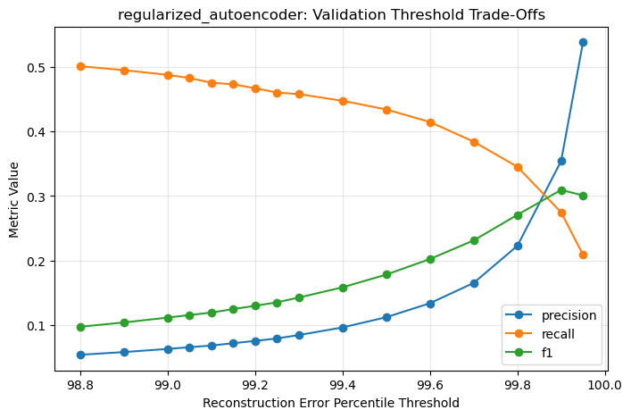

```
Threshold results for narrow_bottleneck_autoencoder
```

|  | percentile | threshold | precision | recall | f1 | tn | fp | fn | tp | predicted_anomalies | predicted_anomaly_rate |
| --- | --- | --- | --- | --- | --- | --- | --- | --- | --- | --- | --- |
| 0 | 99.90 | 3.209007 | 0.362137 | 0.280755 | 0.316295 | 1270070 | 812 | 1181 | 461 | 1273 | 0.001000 |
| 1 | 99.95 | 7.475349 | 0.543171 | 0.210719 | 0.303642 | 1270591 | 291 | 1296 | 346 | 637 | 0.000501 |
| 2 | 99.80 | 1.245762 | 0.237328 | 0.367844 | 0.288512 | 1268941 | 1941 | 1038 | 604 | 2545 | 0.002000 |
| 3 | 99.70 | 0.912960 | 0.173389 | 0.403167 | 0.242491 | 1267726 | 3156 | 980 | 662 | 3818 | 0.003000 |
| 4 | 99.60 | 0.718951 | 0.136319 | 0.422655 | 0.206149 | 1266485 | 4397 | 948 | 694 | 5091 | 0.004001 |
| 5 | 99.50 | 0.611017 | 0.112997 | 0.437881 | 0.179638 | 1265238 | 5644 | 923 | 719 | 6363 | 0.005000 |
| 6 | 99.40 | 0.541347 | 0.096386 | 0.448234 | 0.158655 | 1263982 | 6900 | 906 | 736 | 7636 | 0.006001 |
| 7 | 99.30 | 0.491671 | 0.084531 | 0.458587 | 0.142749 | 1262727 | 8155 | 889 | 753 | 8908 | 0.007000 |
| 8 | 99.25 | 0.469531 | 0.079736 | 0.463459 | 0.136063 | 1262099 | 8783 | 881 | 761 | 9544 | 0.007500 |
| 9 | 99.20 | 0.450694 | 0.074845 | 0.464068 | 0.128901 | 1261463 | 9419 | 880 | 762 | 10181 | 0.008001 |
| 10 | 99.15 | 0.433011 | 0.070999 | 0.467722 | 0.123284 | 1260833 | 10049 | 874 | 768 | 10817 | 0.008500 |
| 11 | 99.10 | 0.418927 | 0.067319 | 0.469549 | 0.117755 | 1260200 | 10682 | 871 | 771 | 11453 | 0.009000 |
| 12 | 99.05 | 0.404964 | 0.064356 | 0.473812 | 0.113320 | 1259571 | 11311 | 864 | 778 | 12089 | 0.009500 |
| 13 | 99.00 | 0.391849 | 0.061370 | 0.475639 | 0.108714 | 1258937 | 11945 | 861 | 781 | 12726 | 0.010001 |
| 14 | 98.90 | 0.368176 | 0.056722 | 0.483557 | 0.101535 | 1257678 | 13204 | 848 | 794 | 13998 | 0.011000 |
| 15 | 98.80 | 0.348494 | 0.052780 | 0.490865 | 0.095311 | 1256417 | 14465 | 836 | 806 | 15271 | 0.012001 |

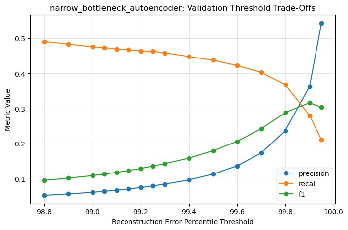

```
Threshold results for wide_regularized_autoencoder
```

|  | percentile | threshold | precision | recall | f1 | tn | fp | fn | tp | predicted_anomalies | predicted_anomaly_rate |
| --- | --- | --- | --- | --- | --- | --- | --- | --- | --- | --- | --- |
| 0 | 99.90 | 1.106182 | 0.379419 | 0.294153 | 0.331389 | 1270092 | 790 | 1159 | 483 | 1273 | 0.001000 |
| 1 | 99.80 | 0.504242 | 0.237721 | 0.368453 | 0.288990 | 1268942 | 1940 | 1037 | 605 | 2545 | 0.002000 |
| 2 | 99.95 | 4.671501 | 0.445840 | 0.172960 | 0.249232 | 1270529 | 353 | 1358 | 284 | 637 | 0.000501 |
| 3 | 99.70 | 0.359065 | 0.174175 | 0.404994 | 0.243590 | 1267729 | 3153 | 977 | 665 | 3818 | 0.003000 |
| 4 | 99.60 | 0.294606 | 0.136908 | 0.424482 | 0.207040 | 1266488 | 4394 | 945 | 697 | 5091 | 0.004001 |
| 5 | 99.50 | 0.259033 | 0.112526 | 0.436054 | 0.178888 | 1265235 | 5647 | 926 | 716 | 6363 | 0.005000 |
| 6 | 99.40 | 0.234825 | 0.095469 | 0.443971 | 0.157146 | 1263975 | 6907 | 913 | 729 | 7636 | 0.006001 |
| 7 | 99.30 | 0.215565 | 0.083296 | 0.451888 | 0.140664 | 1262716 | 8166 | 900 | 742 | 8908 | 0.007000 |
| 8 | 99.25 | 0.207501 | 0.078688 | 0.457369 | 0.134275 | 1262089 | 8793 | 891 | 751 | 9544 | 0.007500 |
| 9 | 99.20 | 0.199999 | 0.074452 | 0.461632 | 0.128225 | 1261459 | 9423 | 884 | 758 | 10181 | 0.008001 |
| 10 | 99.15 | 0.192336 | 0.070630 | 0.465286 | 0.122642 | 1260829 | 10053 | 878 | 764 | 10817 | 0.008500 |
| 11 | 99.10 | 0.186045 | 0.067144 | 0.468331 | 0.117449 | 1260198 | 10684 | 873 | 769 | 11453 | 0.009000 |
| 12 | 99.05 | 0.180326 | 0.064191 | 0.472594 | 0.113029 | 1259569 | 11313 | 866 | 776 | 12089 | 0.009500 |
| 13 | 99.00 | 0.174778 | 0.061370 | 0.475639 | 0.108714 | 1258937 | 11945 | 861 | 781 | 12726 | 0.010001 |
| 14 | 98.90 | 0.164318 | 0.056365 | 0.480512 | 0.100895 | 1257673 | 13209 | 853 | 789 | 13998 | 0.011000 |
| 15 | 98.80 | 0.155257 | 0.052976 | 0.492692 | 0.095666 | 1256420 | 14462 | 833 | 809 | 15271 | 0.012001 |

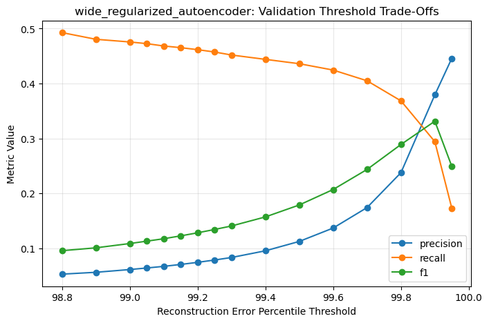

```python
for config_name, threshold_df in threshold_results.items():
    print(f"Threshold results for {config_name}")
    display(threshold_df)

    plot_df = threshold_df.sort_values("percentile")

    plt.figure(figsize=(8, 5))
    plt.plot(plot_df["percentile"], plot_df["precision"], marker="o", label="precision")
    plt.plot(plot_df["percentile"], plot_df["recall"], marker="o", label="recall")
    plt.plot(plot_df["percentile"], plot_df["f1"], marker="o", label="f1")
    plt.title(f"{config_name}: Validation Threshold Trade-Offs")
    plt.xlabel("Reconstruction Error Percentile Threshold")
    plt.ylabel("Metric Value")
    plt.legend()
    plt.grid(True, alpha=0.3)
    plt.show()
```

## 10. Select Best Autoencoder Configuration

The best configuration is selected using validation results only. The test set remains untouched until the final evaluation step.

```python
best_config_name = select_best_autoencoder_config_for_review_policy(
    validation_results_df,
    max_review_rate=MAX_REVIEW_RATE,
    min_precision=MIN_PRECISION,
)

best_autoencoder_model = fitted_models[best_config_name]
best_threshold = thresholds[best_config_name]
config_column = "config_name" if "config_name" in validation_results_df.columns else "model"
best_validation_row = validation_results_df[
    validation_results_df[config_column] == best_config_name
]

print(f"Best Autoencoder configuration: {best_config_name}")
print(f"Best validation threshold: {best_threshold:.8f}")

display(best_validation_row)
display(threshold_results[best_config_name])
```

```
Best Autoencoder configuration: small_autoencoder
Best validation threshold: 0.38420203
```

|  | model | threshold | accuracy | precision | recall | f1 | roc_auc | pr_auc | average_precision | tn | fp | fn | tp | config_name | selected_percentile | predicted_anomaly_rate | max_review_rate | min_precision | review_policy_satisfied | selection_policy |
| --- | --- | --- | --- | --- | --- | --- | --- | --- | --- | --- | --- | --- | --- | --- | --- | --- | --- | --- | --- | --- |
| 0 | small_autoencoder | 0.384202 | 0.99053 | 0.069485 | 0.511571 | 0.122351 | 0.933211 | 0.295107 | 0.295107 | 1259633 | 11249 | 802 | 840 | small_autoencoder | 99.05 | 0.0095 | 0.01 | 0.05 | True | maximize_recall_under_review_budget |

|  | percentile | threshold | precision | recall | f1 | tn | fp | fn | tp | predicted_anomalies | predicted_anomaly_rate |
| --- | --- | --- | --- | --- | --- | --- | --- | --- | --- | --- | --- |
| 0 | 99.95 | 5.886664 | 0.642072 | 0.249086 | 0.358929 | 1270654 | 228 | 1233 | 409 | 637 | 0.000501 |
| 1 | 99.90 | 3.379517 | 0.389631 | 0.302071 | 0.340309 | 1270105 | 777 | 1146 | 496 | 1273 | 0.001000 |
| 2 | 99.80 | 1.713277 | 0.233399 | 0.361754 | 0.283735 | 1268931 | 1951 | 1048 | 594 | 2545 | 0.002000 |
| 3 | 99.70 | 1.089725 | 0.174961 | 0.406821 | 0.244689 | 1267732 | 3150 | 974 | 668 | 3818 | 0.003000 |
| 4 | 99.60 | 0.763291 | 0.141622 | 0.439099 | 0.214169 | 1266512 | 4370 | 921 | 721 | 5091 | 0.004001 |
| 5 | 99.50 | 0.614763 | 0.118655 | 0.459805 | 0.188632 | 1265274 | 5608 | 887 | 755 | 6363 | 0.005000 |
| 6 | 99.40 | 0.531979 | 0.102017 | 0.474421 | 0.167924 | 1264025 | 6857 | 863 | 779 | 7636 | 0.006001 |
| 7 | 99.30 | 0.473796 | 0.089358 | 0.484775 | 0.150900 | 1262770 | 8112 | 846 | 796 | 8908 | 0.007000 |
| 8 | 99.25 | 0.451227 | 0.084241 | 0.489647 | 0.143751 | 1262142 | 8740 | 838 | 804 | 9544 | 0.007500 |
| 9 | 99.20 | 0.431551 | 0.079658 | 0.493910 | 0.137190 | 1261512 | 9370 | 831 | 811 | 10181 | 0.008001 |
| 10 | 99.15 | 0.413933 | 0.076176 | 0.501827 | 0.132274 | 1260889 | 9993 | 818 | 824 | 10817 | 0.008500 |
| 11 | 99.10 | 0.398303 | 0.072645 | 0.506699 | 0.127071 | 1260261 | 10621 | 810 | 832 | 11453 | 0.009000 |
| 12 | 99.05 | 0.384202 | 0.069485 | 0.511571 | 0.122351 | 1259633 | 11249 | 802 | 840 | 12089 | 0.009500 |
| 13 | 99.00 | 0.370923 | 0.066714 | 0.517052 | 0.118179 | 1259005 | 11877 | 793 | 849 | 12726 | 0.010001 |
| 14 | 98.90 | 0.346729 | 0.061437 | 0.523752 | 0.109974 | 1257744 | 13138 | 782 | 860 | 13998 | 0.011000 |
| 15 | 98.80 | 0.326833 | 0.056774 | 0.528015 | 0.102525 | 1256478 | 14404 | 775 | 867 | 15271 | 0.012001 |

## 11. Final Autoencoder Evaluation on Test Set

The test set is used only after validation-based threshold and configuration selection. The final test result estimates how the selected review policy performs on unseen transactions.

```python
test_reconstruction_errors = calculate_reconstruction_errors(
    best_autoencoder_model,
    X_test_ae,
)

test_autoencoder_metrics = evaluate_autoencoder_anomaly_detector(
    reconstruction_errors=test_reconstruction_errors,
    y_true=y_test,
    threshold=best_threshold,
    model_name=f"Autoencoder ({best_config_name})",
)

test_metrics_df = pd.DataFrame([test_autoencoder_metrics])
test_metrics_path = REPORTS_DIR / "autoencoder_1m_test_evaluation.csv"
test_metrics_df.to_csv(test_metrics_path, index=False)

print(f"Saved Autoencoder test evaluation to: {test_metrics_path}")
test_metrics_df
```

```
Saved Autoencoder test evaluation to: d:\cs s1 26\基于深度学习的交易欺诈检测与智能风控系统\transaction-fraud-detection-system\reports\autoencoder_1m_test_evaluation.csv
```

|  | model | threshold | accuracy | precision | recall | f1 | roc_auc | pr_auc | average_precision | tn | fp | fn | tp |
| --- | --- | --- | --- | --- | --- | --- | --- | --- | --- | --- | --- | --- | --- |
| 0 | Autoencoder (small_autoencoder) | 0.384202 | 0.990392 | 0.065737 | 0.487523 | 0.115852 | 0.93858 | 0.28005 | 0.28005 | 1259497 | 11384 | 842 | 801 |

## 12. Visualize Test Reconstruction Error Distribution

Fraud transactions are expected to have higher reconstruction errors if they deviate from normal transaction patterns. However, overlap between normal and fraud errors is expected.

Because fraud cases are extremely rare, raw count histograms can be hard to read: the normal class dominates the bars. The plots below use log-transformed reconstruction errors and density-based histograms so the normal and fraud distributions can be compared more clearly.

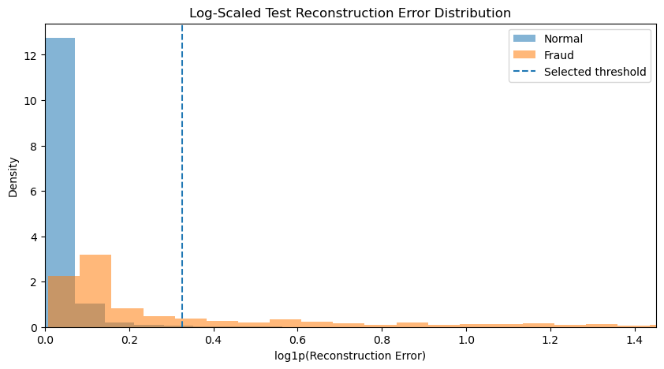

```python
test_error_plot_df = pd.DataFrame(
    {
        "reconstruction_error": test_reconstruction_errors,
        "isFraud": y_test.to_numpy(),
    }
)

normal_errors = test_error_plot_df.loc[test_error_plot_df["isFraud"] == 0, "reconstruction_error"]
fraud_errors = test_error_plot_df.loc[test_error_plot_df["isFraud"] == 1, "reconstruction_error"]

log_normal_errors = np.log1p(normal_errors)
log_fraud_errors = np.log1p(fraud_errors)
log_threshold = np.log1p(best_threshold)

upper_plot_limit = np.percentile(
    np.concatenate([log_normal_errors.to_numpy(), log_fraud_errors.to_numpy()]),
    99.9,
)

plt.figure(figsize=(10, 5))
plt.hist(log_normal_errors, bins=80, alpha=0.55, density=True, label="Normal")
plt.hist(log_fraud_errors, bins=80, alpha=0.55, density=True, label="Fraud")
plt.axvline(log_threshold, linestyle="--", label="Selected threshold")
plt.xlim(0, upper_plot_limit)
plt.title("Log-Scaled Test Reconstruction Error Distribution")
plt.xlabel("log1p(Reconstruction Error)")
plt.ylabel("Density")
plt.legend()
plt.show()
```

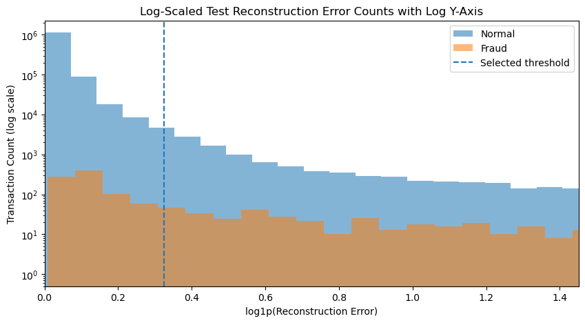

```python
plt.figure(figsize=(10, 5))
plt.hist(log_normal_errors, bins=80, alpha=0.55, label="Normal")
plt.hist(log_fraud_errors, bins=80, alpha=0.55, label="Fraud")
plt.axvline(log_threshold, linestyle="--", label="Selected threshold")
plt.yscale("log")
plt.xlim(0, upper_plot_limit)
plt.title("Log-Scaled Test Reconstruction Error Counts with Log Y-Axis")
plt.xlabel("log1p(Reconstruction Error)")
plt.ylabel("Transaction Count (log scale)")
plt.legend()
plt.show()
```

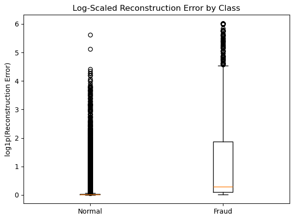

```python
plt.figure(figsize=(7, 5))
plt.boxplot(
    [np.log1p(normal_errors), np.log1p(fraud_errors)],
    labels=["Normal", "Fraud"],
)
plt.title("Log-Scaled Reconstruction Error by Class")
plt.ylabel("log1p(Reconstruction Error)")
plt.show()
```

## 13. Create Reconstruction Error Output for Notebook 05

This file can be used later in notebook 05 as an anomaly signal for integrated risk scoring.

```python
test_error_df = create_reconstruction_error_dataframe(
    reconstruction_errors=test_reconstruction_errors,
    y_true=y_test,
    threshold=best_threshold,
)

test_error_path = REPORTS_DIR / "autoencoder_1m_test_reconstruction_errors.csv"
test_error_df.to_csv(test_error_path, index=False)

print(f"Saved test reconstruction errors to: {test_error_path}")
test_error_df.head()
```

```
Saved test reconstruction errors to: d:\cs s1 26\基于深度学习的交易欺诈检测与智能风控系统\transaction-fraud-detection-system\reports\autoencoder_1m_test_reconstruction_errors.csv
```

|  | reconstruction_error | anomaly_score | is_anomaly_predicted | isFraud |
| --- | --- | --- | --- | --- |
| 0 | 0.044790 | 0.044790 | 0 | 0 |
| 1 | 0.009182 | 0.009182 | 0 | 0 |
| 2 | 0.044269 | 0.044269 | 0 | 0 |
| 3 | 0.012685 | 0.012685 | 0 | 0 |
| 4 | 0.004772 | 0.004772 | 0 | 0 |

## 14. Save Autoencoder Artifacts

The selected Autoencoder model, fitted preprocessor, threshold, configuration, and validation metrics are saved for later integration in notebook 05.

```python
best_config = next(
    config for config in configs
    if config["config_name"] == best_config_name
)

best_validation_metrics = best_validation_row.iloc[0].to_dict()
best_validation_metrics.update(
    {
        "max_review_rate": MAX_REVIEW_RATE,
        "min_precision": MIN_PRECISION,
        "selection_policy": "maximize_recall_under_review_budget",
        "selected_percentile": best_validation_metrics.get("selected_percentile"),
    }
)

artifact_paths = save_autoencoder_artifacts(
    model=best_autoencoder_model,
    preprocessor=fitted_ae_preprocessor,
    threshold=best_threshold,
    config=best_config,
    validation_metrics=best_validation_metrics,
    model_path=AUTOENCODER_MODEL_DIR / "autoencoder_model.keras",
    preprocessor_path=AUTOENCODER_MODEL_DIR / "autoencoder_preprocessor.pkl",
    threshold_path=AUTOENCODER_MODEL_DIR / "autoencoder_threshold.json",
)

print("Saved Autoencoder artifacts:")
for artifact_name, artifact_path in artifact_paths.items():
    print(f"- {artifact_name}: {artifact_path}")
```

```
Saved Autoencoder artifacts:
- model_path: d:\cs s1 26\基于深度学习的交易欺诈检测与智能风控系统\transaction-fraud-detection-system\models\autoencoder_1m\autoencoder_model.keras
- preprocessor_path: d:\cs s1 26\基于深度学习的交易欺诈检测与智能风控系统\transaction-fraud-detection-system\models\autoencoder_1m\autoencoder_preprocessor.pkl
- threshold_path: d:\cs s1 26\基于深度学习的交易欺诈检测与智能风控系统\transaction-fraud-detection-system\models\autoencoder_1m\autoencoder_threshold.json
```

## 15. Final Summary

This notebook trains and compares a small set of Autoencoder configurations using a 1,000,000-row normal-only training sample. The best Autoencoder configuration is selected with a recall-oriented validation policy under a review-volume constraint.

The selected validation policy uses `MAX_REVIEW_RATE = 0.01` and `MIN_PRECISION = 0.05`. The selected configuration, percentile threshold, numeric threshold, and final test precision, recall, F1, PR-AUC, ROC-AUC, FP, FN, and TP are reported in the output cells above.

The Autoencoder is evaluated as a supplementary review-queue generator. A higher recall is preferred because the goal is to flag more potentially fraudulent transactions for review, while the review-rate cap prevents the number of false positives from becoming too large.

Previous 500k reference result from notebook 04: best config `small_autoencoder`, selected percentile `99.05`, test precision `0.068548`, test recall `0.506999`, test F1 `0.120768`, test ROC-AUC `0.938367`, test PR-AUC `0.269921`, FP `11319`, FN `810`, and TP `833`. After running this 1M experiment, compare whether test recall, PR-AUC, F1, FP count, and review rate improved enough to justify the larger training sample.

This notebook only checks whether increasing normal training sample size improves the Autoencoder anomaly detection module itself. It does not prove that Autoencoder improves the final fraud detection system. Incremental value beyond Random Forest should still be evaluated separately in notebook 07.

Notebook 05 will integrate supervised Random Forest fraud probability, Autoencoder anomaly score, and business rules into a final risk score, risk level, and recommended action.